# BCB430 Assignment1

Shuzo Fukunaga

2024-02-14

# Introduction

In late 2019, a novel coronavirus, severe acute respiratory synfrome coronavirus 2 (SARS-CoV-2), which cause a severe respiratory disease, emerged in Wuhan, China. The virus spread all over the world, and infected more than 750 million people (WHO 2020). It is reported that patients in different population shows different trend of symptoms. For example, females are less likely to infect SARS-CoV-2 (Steeg 2016). However, mechanisms behind such a difference is still unknown.  
(Lieberman 2020) examined gene expression in response to SARS-CoV-2 infection with shotgun RNA Sequencing to see the gene expression changes. Test condition is 430 SARS-CoV-2 patients and control condition is 54 non-infected individuals.<sup>Q1</sup>  
This dataset fits my interest. I lost my father last year due to COVID19, but almost nothing happened to my mother, who also infected, while both were mostly healthy and fully vaccinated. I would like to know a potential difference between my father and my mother, which is about what of my father led him dead.<sup>Q2</sup>

# Setup

```r
if (!requireNamespace("BiocManager", quietly = TRUE))
  install.packages("BiocManager")
if (!requireNamespace("GEOquery", quietly = TRUE))
  install.packages("GEOquery")
if (!requireNamespace("GEOmetadb", quietly = TRUE))
  BiocManager::install("GEOmetadb")
if (!requireNamespace("biomaRt", quietly = TRUE))
    BiocManager::install("biomaRt")
if (!requireNamespace("edgeR", quietly = TRUE))
  BiocManager::install("edgeR")
if (!requireNamespace("knitr", quietly = TRUE))
  BiocManager::install("knitr")
```

# Data Selection

The criterion for a dataset:  
1. taken from native, healthy human cells or tisssue  
2. interesting  
3. the coverage is as complete as possible  
4. from high-quality experiment  
(Isserlin 2023)

Based on the criteria above, a dataset GSE152075 is chosen. Refer to the detail in [my journal](https://github.com/bcb420-2023/Shuzo_Fukunaga/wiki/1.1-Assignment-1---Data-set-selection-and-initial-Processing).  
Details about the platform is shown below.

Platform Title: Illumina NextSeq 500 (Homo sapiens)  
Submission Data: Apr 15 2014  
Last Update Data: Mar 26 2019  
Organisms: Homo sapiens  
Number of GEO Datasets: 11543  
Number of GEO Samples: 323288

# Data Cleaning

## Download The Data

```r
# Download supplemental file.
suppFiles <- GEOquery::getGEOSuppFiles("GSE152075")
fileNames <- rownames(suppFiles)
# There is only one supplimental file.
# Convert into DataFrame.
covid_exp <- read.delim(fileNames[1], header=TRUE, check.names = FALSE, sep=" ")
```

## Assess

```r
# Shows a part of the dataset as a sample.
# The beginning of the dataset.
knitr::kable(covid_exp[1:15,1:5], format = "html")
```

|  | POS_001 | POS_002 | POS_003 | POS_004 | POS_005 |
| --- | --- | --- | --- | --- | --- |
| A1BG | 0 | 1 | 0 | 0 | 18 |
| A1CF | 0 | 0 | 2 | 0 | 0 |
| A2M | 69 | 36 | 84 | 42 | 83 |
| A2ML1 | 2 | 0 | 0 | 0 | 3 |
| A2MP1 | 0 | 0 | 0 | 0 | 21 |
| A3GALT2 | 0 | 0 | 0 | 0 | 0 |
| A4GALT | 0 | 11 | 2 | 0 | 2 |
| A4GNT | 0 | 19 | 0 | 0 | 0 |
| AAAS | 4 | 0 | 0 | 0 | 0 |
| AACS | 2 | 33 | 2 | 0 | 27 |
| AACSP1 | 0 | 0 | 0 | 0 | 0 |
| AADAC | 0 | 0 | 0 | 0 | 0 |
| AADACL2 | 0 | 0 | 4 | 4 | 0 |
| AADACL3 | 0 | 0 | 0 | 0 | 4 |
| AADACL4 | 0 | 0 | 0 | 0 | 0 |

```r
# The end of the test samples and the beginning of the controls.
knitr::kable(covid_exp[1:15, 428:432], format = "html")
```

|  | POS_436 | POS_437 | POS_438 | NEG_001 | NEG_002 |
| --- | --- | --- | --- | --- | --- |
| A1BG | 0 | 20 | 219 | 21 | 18 |
| A1CF | 0 | 0 | 55 | 15 | 1 |
| A2M | 120 | 62 | 23 | 55 | 121 |
| A2ML1 | 0 | 16 | 39 | 5 | 8 |
| A2MP1 | 0 | 2 | 0 | 0 | 0 |
| A3GALT2 | 0 | 0 | 0 | 0 | 0 |
| A4GALT | 0 | 63 | 9 | 9 | 10 |
| A4GNT | 0 | 0 | 0 | 0 | 0 |
| AAAS | 0 | 22 | 11 | 35 | 42 |
| AACS | 4 | 67 | 119 | 45 | 10 |
| AACSP1 | 0 | 6 | 0 | 0 | 0 |
| AADAC | 0 | 0 | 0 | 19 | 0 |
| AADACL2 | 0 | 28 | 55 | 208 | 36 |
| AADACL3 | 0 | 0 | 3 | 0 | 1 |
| AADACL4 | 0 | 0 | 0 | 0 | 0 |

```r
# The end of the controls.
knitr::kable(covid_exp[1:15, 480:484], format = "html")
```

|  | NEG_059 | NEG_060 | NEG_062 | NEG_063 | NEG_065 |
| --- | --- | --- | --- | --- | --- |
| A1BG | 1 | 0 | 0 | 0 | 1 |
| A1CF | 0 | 0 | 0 | 0 | 2 |
| A2M | 45 | 0 | 10 | 0 | 54 |
| A2ML1 | 3 | 2 | 0 | 47 | 2 |
| A2MP1 | 1 | 0 | 0 | 0 | 0 |
| A3GALT2 | 1 | 0 | 0 | 0 | 0 |
| A4GALT | 20 | 4 | 3 | 6 | 0 |
| A4GNT | 0 | 0 | 0 | 0 | 0 |
| AAAS | 14 | 13 | 10 | 0 | 1 |
| AACS | 19 | 18 | 22 | 16 | 13 |
| AACSP1 | 1 | 0 | 0 | 0 | 0 |
| AADAC | 0 | 0 | 1 | 0 | 0 |
| AADACL2 | 5 | 1 | 4 | 0 | 60 |
| AADACL3 | 0 | 0 | 1 | 0 | 0 |
| AADACL4 | 0 | 0 | 0 | 0 | 0 |

The leftmost column shows genes and the others represents each samples. POS means a sample from SARS-CoV-2 Positive patients, while NEG means a sample from control. Note that samples range from POS_001 to POS_438 and NEG_001 to NEG_065, while there are 430 testing samples and 54 control samples. This is because some samples are omitted e.g.NEG_061. Note that further details about patients are not submitted by the author for a privacy reason.

```r
# The number of genes.
dim(covid_exp)
```

```
## [1] 35784   484
```

```r
# Make sure the number of testing/control samples are not wrong.
length(grep("POS", colnames(covid_exp)))
```

```
## [1] 430
```

```r
length(grep("NEG", colnames(covid_exp)))
```

```
## [1] 54
```

There are 35784 genes in this dataset, and 430 samples from SARS-CoV-2 patients i.e. testing samples and 54 samples from controls as documented in the article.

```r
# The number of duplicated genes.
sum(duplicated(rownames(covid_exp)))
```

```
## [1] 0
```

There is no duplicated genes.<sup>Q3</sup><sup>Q6</sup>

## Map

To list non-HUGO gene symbols, serach for an appropriate attribute.

```r
# Look for an appropriate attribute for HGNC symbols.
ensembl <- biomaRt::useMart(biomart="ensembl", dataset="hsapiens_gene_ensembl")
biomaRt::searchAttributes(mart = ensembl, "hgnc")
```

```
##               name        description         page
## 62         hgnc_id            HGNC ID feature_page
## 63     hgnc_symbol        HGNC symbol feature_page
## 93 hgnc_trans_name Transcript name ID feature_page
```

`hgnc_symbol` will be used.

```r
# Load the saved result if exists, because it can be computationally expensive.
filename <- "covid_exp_hgnc.rds"
if (file.exists(filename)) {
  hgnc <- readRDS(filename)
# Save the result.
} else {
# HUGO gene symbols listed.
  hgnc <- biomaRt::getBM(attributes = "hgnc_symbol",
                         filters = "hgnc_symbol",
                         values = rownames(covid_exp),
                         mart = ensembl)
  saveRDS(hgnc, filename)
}
non_hugo <- rownames(covid_exp)[!(rownames(covid_exp) %in% hgnc$hgnc_symbol)]
head(non_hugo)
```

```
## [1] "ABBA01000935.1" "ABBA01000935.2" "ABBA01006766.1" "ABHD11-AS1"
## [5] "AC000041.1"     "AC000077.1"
```

These non-HUGO gene symbols are GenBank accession numbers.  
GenBank accession numbers can be referred by an attribute named “protein_id” in Bio.(wiggs38 2016) Note that GenBank accession numbers are called INSDC numbers in HGNC documentation.(HGNC, n.d.)

```r
# Look for an appropriate attribute for INSDC.
# searchAttributes(mart = ensembl, "genbank")
# The code above does not work.
# An attribute named "protein_id" is used for GenBank accession numbers.
biomaRt::searchAttributes(mart = ensembl, "protein_id")
```

```
##          name      description         page
## 66 protein_id INSDC protein ID feature_page
```

```r
# Make sure non-HUGO gene symbols are GenBank accession numbers.
filename <- "covid_exp_genbank.rds"
if (file.exists(filename)) {
  genBank <- readRDS(filename)
# Save the result.
} else {
# HUGO gene symbols listed.
  genBank <- biomaRt::getBM(attributes = "protein_id",
                            values = rownames(covid_exp),
                            mart = ensembl)
  saveRDS(genBank, filename)
}
# Numbers after a period, which refers to a version, is omitted from GenBank accession numbers, because any version is included in genBank$protein_id.
non_hugo_mod <- gsub("\\..*", "", non_hugo)
non_hugo_genbank <- non_hugo[!(non_hugo %in% genBank$protein_id)]
# The number of mathced genes.
sum(!(non_hugo == non_hugo_genbank))
```

```
## [1] 0
```

It was unable to convert GenBank accession numbers into HUGO gene symbols.<sup>Q4</sup> This is likely because those with GenBank accession numbers are not genes. For example, ABBA01000935.1 is a sequence obtained by whole genome shotgun sequence(Levy and Venter 2007). These non-gene sequences will be removed in clean section

## Clean

### Filter Low Counts Out

```r
# Count counts per million.
cpms <- edgeR::cpm(covid_exp)
# Following edgeR criteria, remove features without at least 1 read per million in the number of smallest samples.
# The control samples are the smallest in size, which is 54.
keep <- rowSums(cpms > 1) >= 54
covid_exp_no_lowcounts <- covid_exp[keep,]
dim(covid_exp_no_lowcounts)
```

```
## [1] 15630   484
```

Thus, 20154 samples are removed for low counts. Note that this does not affect the duplicates, as there is no duplicates first of all.

### Remove Those with GenBank Accession Numbers

```r
covid_exp_no_lowcounts_no_accession_num <- covid_exp_no_lowcounts[(rownames(covid_exp_no_lowcounts) %in% hgnc$hgnc_symbol),]
```

620 samples with GenBank Accession numbers are removed.

### Remove outliers

```r
covid_exp_pos1_neg1 <- cbind(covid_exp_no_lowcounts_no_accession_num[,1],
                             covid_exp_no_lowcounts_no_accession_num[, 431])
colnames(covid_exp_pos1_neg1) <- c(colnames(covid_exp_no_lowcounts_no_accession_num[1]),
                                   colnames(covid_exp_no_lowcounts_no_accession_num[431]))
data2plot <- log2(edgeR::cpm(covid_exp_pos1_neg1))
summary(data2plot)
```

```
##     POS_001          NEG_001
##  Min.   :  -Inf   Min.   :  -Inf
##  1st Qu.:  -Inf   1st Qu.: 2.440
##  Median : 2.657   Median : 4.248
##  Mean   :  -Inf   Mean   :  -Inf
##  3rd Qu.: 4.657   3rd Qu.: 5.726
##  Max.   :16.881   Max.   :15.695
```

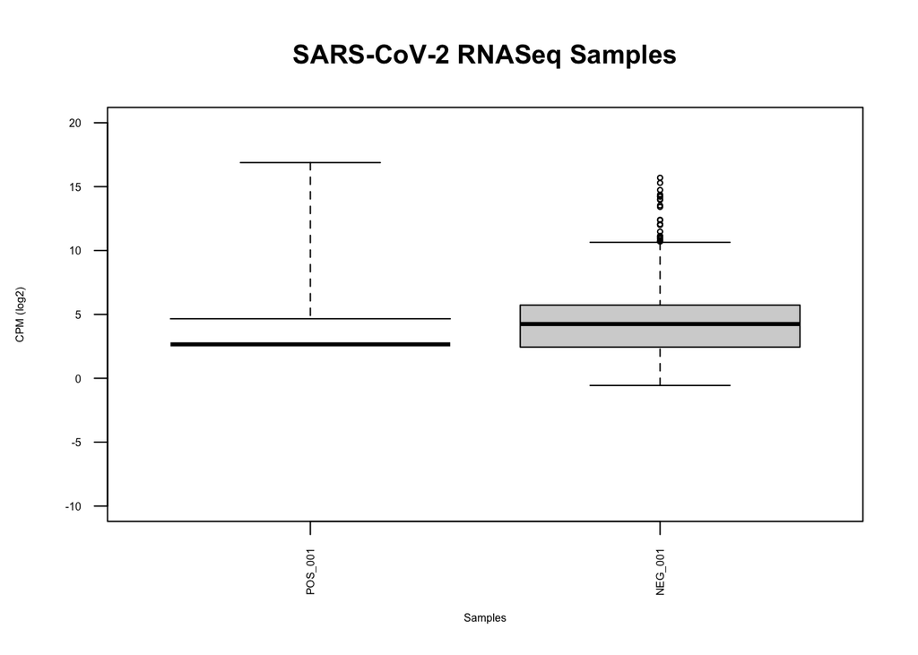

```r
boxplot(data2plot,
        xlab = "Samples",
        ylab = "CPM (log2)",
        las = 2,
        cex = 0.5,
        cex.lab = 0.5,
        cex.axis = 0.5,
        ylim = c(-10, 20),
        main = "SARS-CoV-2 RNASeq Samples")
```

# Normalization

## TMM Normalization

Create SARS-CoV-2 positive/negative groups.

```r
samples <- data.frame(lapply(colnames(covid_exp_no_lowcounts_no_accession_num),
                             FUN=function(x){unlist(strsplit(x, split = "_"))[c(2,1)]}))
colnames(samples) <- colnames(covid_exp_no_lowcounts_no_accession_num)
rownames(samples) <- c("individual","SARS-CoV-2")
samples <- data.frame(t(samples))
```

Create DGEList object.

```r
filtered_data_matrix <- as.matrix(covid_exp_no_lowcounts_no_accession_num)
rownames(filtered_data_matrix) <- rownames(covid_exp_no_lowcounts_no_accession_num)
d <- edgeR::DGEList(counts=filtered_data_matrix, group=samples$cell_type)
```

Normalize with Trimmed mean of M-values (TMM)

```r
d <- edgeR::calcNormFactors(d)
normalized_counts <- edgeR::cpm(d)
# Save as .txt file for future assignments.
write.table(normalized_counts, file.path(getwd(), "normalized_counts.txt"))
```

## MDS Plot

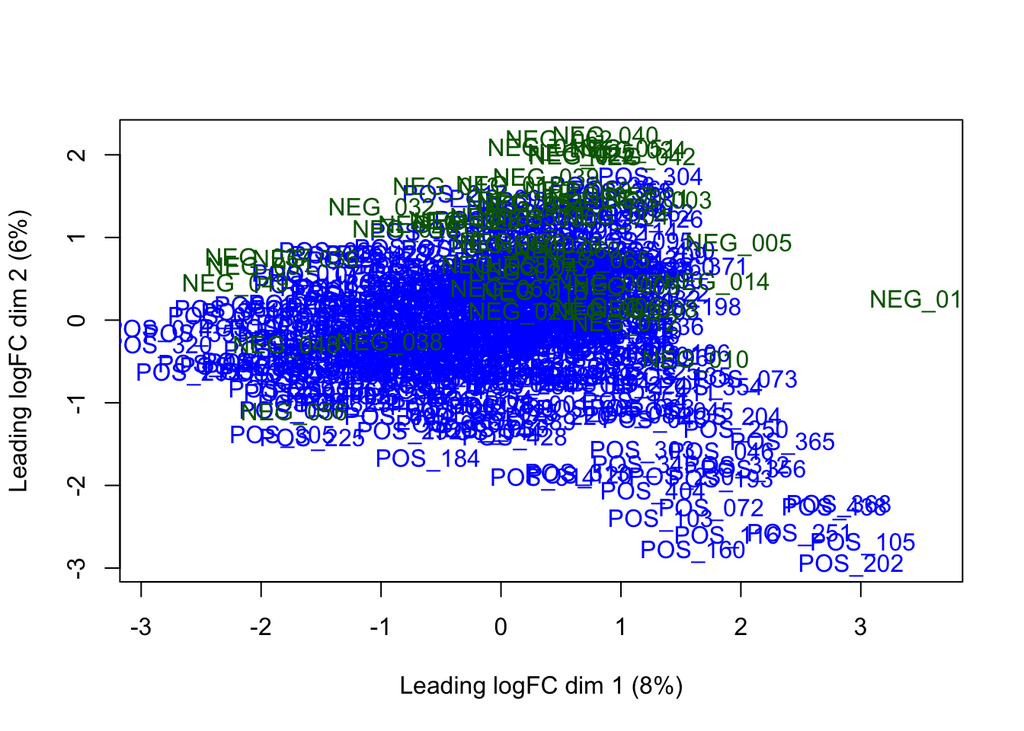

```r
limma::plotMDS(d,
               labels=rownames(samples),
               col = c("darkgreen","blue")[factor(samples$SARS.CoV.2)])
```

## Density Plot

A density plot before normalization.

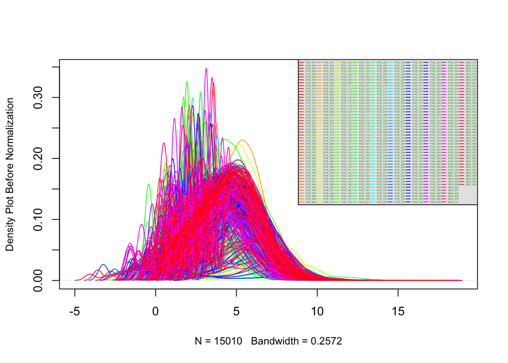

```r
counts_density <- apply(log2(edgeR::cpm(covid_exp_no_lowcounts_no_accession_num)), 2, density)
xlim <- 0
ylim <- 0
for (i in 1:length(counts_density)) {
  xlim <- range(c(xlim, counts_density[[i]]$x))
  ylim <- range(c(ylim, counts_density[[i]]$y))
  }
cols <- rainbow(length(counts_density))
ltys <- rep(1, length(counts_density))

#plot the first density plot to initialize the plot
plot(counts_density[[1]],
     xlim=xlim,
     ylim=ylim,
     type="n",
     ylab="Density Plot Before Normalization",
     main="",
     cex.lab = 0.85)

#plot each line
for (i in 1:length(counts_density)) {
  lines(counts_density[[i]], col=cols[i], lty=ltys[i])
  }
#create legend
legend("topright",
       colnames(covid_exp_no_lowcounts_no_accession_num),
       col=cols,
       lty=ltys,
       cex=0.2,
       border ="blue",
       text.col = "green4",
       merge = TRUE,
       bg = "gray90",
       ncol=10)
```

A density plot after normalization.

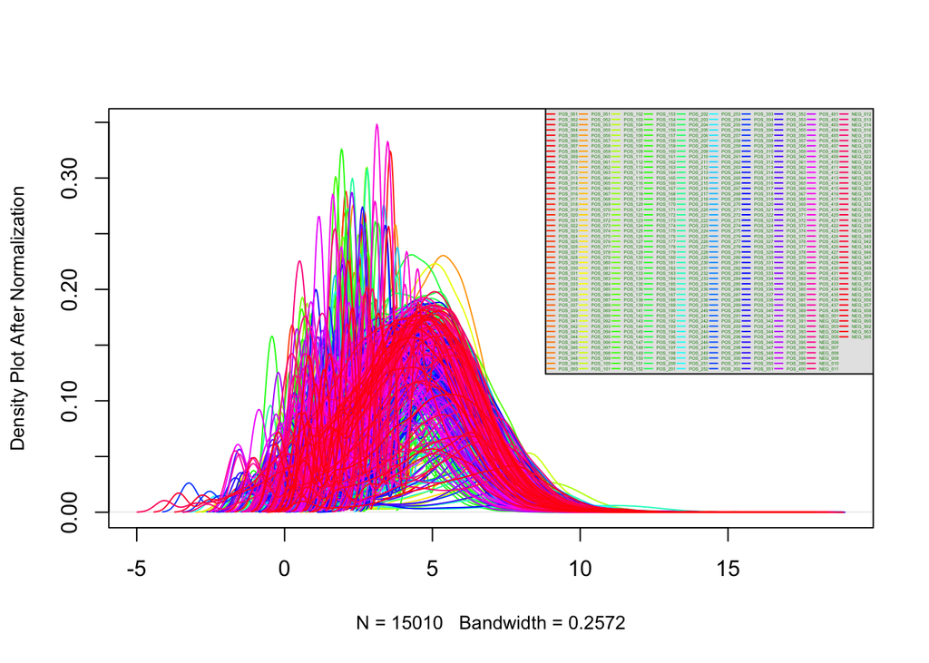

```r
counts_density <- apply(log2(edgeR::cpm(normalized_counts)), 2, density)
xlim <- 0
ylim <- 0
for (i in 1:length(counts_density)) {
  xlim <- range(c(xlim, counts_density[[i]]$x))
  ylim <- range(c(ylim, counts_density[[i]]$y))
  }
cols <- rainbow(length(counts_density))
ltys <- rep(1, length(counts_density))

#plot the first density plot to initialize the plot
plot(counts_density[[1]],
     xlim=xlim,
     ylim=ylim,
     type="n",
     ylab="Density Plot After Normalization",
     main="",
     cex.lab = 0.85)

#plot each line
for (i in 1:length(counts_density)) {
  lines(counts_density[[i]], col=cols[i], lty=ltys[i])
  }
#create legend
legend("topright",
       colnames(normalized_counts),
       col=cols,
       lty=ltys,
       cex=0.2,
       border ="blue",
       text.col = "green4",
       merge = TRUE,
       bg = "gray90",
       ncol=10)
```

# Main Questions for Report

What are the control and test conditions of the dataset?  
Why is the dataset of interest to you?  
Were there expression values that were not unique for specific genes? How did you handle these?  
Were there expression values that could not be mapped to current HUGO symbols?  
How many outliers were removed?  
How did you handle replicates?  
What is the final coverage of your dataset?

# Reference

Isserlin, Ruth. 2023. “BCB420 Assignment1.” https://q.utoronto.ca/courses/294979/assignments/990544.

Levy, Sutton, S., and J.C. Venter. 2007. “Homo Sapiens CTG_1103279016282, Whole Genome Shotgun Sequence.” https://www.ncbi.nlm.nih.gov/nuccore/ABBA01000935.

Lieberman, Vikas AND Xie, Nicole A. P. AND Peddu. 2020. “In Vivo Antiviral Host Transcriptional Response to SARS-CoV-2 by Viral Load, Sex, and Age.” *PLOS Biology* 18 (9): 1–17. https://doi.org/10.1371/journal.pbio.3000849.

Steeg, Sabra L. vom, Landon G. AND Klein. 2016. “SeXX Matters in Infectious Disease Pathogenesis.” *PLOS Pathogens* 12 (2): 1–6. https://doi.org/10.1371/journal.ppat.1005374.

WHO. 2020. “WHO Coronavirus (COVID-19) Dashboard.” https://covid19.who.int.

wiggs38. 2016. “How Can i Convert a List of Genbank Accession Number to Gene Symbols?” https://www.biostars.org/p/213008/.